# Longitudinal Analysis of Academic Growth Patterns at Morningside Academy: A Five-Year Assessment Study

### Research Question 1

#### *Analytic Strategy*

A repeated measures analysis of variance (ANOVA) was conducted via the `aov` function in R to quantify patterns of academic growth across different assessment measure types. Individual measure types were aggregated by domain across participants to create three, composite academic domains of math, reading, and writing.. The repeated measures approach was utilized because growth scores were measured several times for each student across several assessment types within a given year (as well as during multiple years). Thus, we treated `assessment_type` as a within-subject factor. Since the data included non-unique student IDs, the model accounted for repeated measures per student. Post-hoc pairwise comparisons with Bonferroni correction were conducted to determine specific differences between the three assessment types, to account for uneven sample sizes within `year`.

#### *Results*

```
##
## Error: id
##                  Df Sum Sq Mean Sq F value   Pr(>F)
## Assessment_Type   2   24.5  12.275   5.806  0.00341 **
## year              3   58.8  19.603   9.273 7.59e-06 ***
## Residuals       259  547.5   2.114
## ---
## Signif. codes:  0 '***' 0.001 '**' 0.01 '*' 0.05 '.' 0.1 ' ' 1
##
## Error: id:Assessment_Type
##                  Df Sum Sq Mean Sq F value   Pr(>F)
## Assessment_Type   2   22.3  11.159   7.416 0.000687 ***
## year              1    0.9   0.927   0.616 0.432913
## Residuals       402  604.9   1.505
## ---
## Signif. codes:  0 '***' 0.001 '**' 0.01 '*' 0.05 '.' 0.1 ' ' 1
##
## Error: id:year
##           Df Sum Sq Mean Sq F value Pr(>F)
## year       1   0.92  0.9153    0.81  0.372
## Residuals 53  59.87  1.1296
##
## Error: id:Assessment_Type:year
##           Df Sum Sq Mean Sq F value Pr(>F)
## Residuals 33  35.64    1.08
```

```
##
##  Pairwise comparisons using t tests with pooled SD
##
## data:  analysis_long$Growth_Score and analysis_long$Assessment_Type
##
##         Math   Reading
## Reading 0.0147 -
## Writing 1.0000 0.0031
##
## P value adjustment method: bonferroni
```

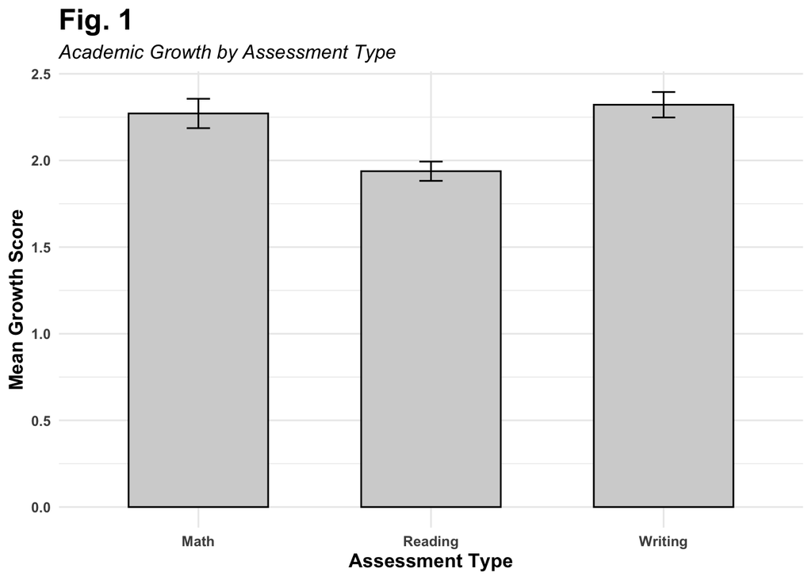

### Research Question 2

#### *Analytic Strategy*

To examine how academic growth varied across different academic years, a linear mixed-effects model (LMM) was conducted, using the `lmer` and `lm` functions within R, in addition to `car` , `lme4` , and `lmertest` for relevant statistics of significance in the LMM outputs. Academic `year` was utilized as a fixed effect, with student ID included as a random effect to account for repeated measurements, due to certain students appearing in the data set multiple times across years. This method allowed us to model within-student variability while estimating the average effect of academic year on academic growth in reading, writing, and math. The LMM was fit using restricted maximum likelihood (REML) for unbiased estimates of fixed and random effects.

### Results

#### *Reading*

```
## Linear mixed model fit by REML. t-tests use Satterthwaite's method [
## lmerModLmerTest]
## Formula: reading ~ year + (1 | id)
##    Data: analysis_avgs
##
## REML criterion at convergence: 759.4
##
## Scaled residuals:
##     Min      1Q  Median      3Q     Max
## -2.5706 -0.6456 -0.0186  0.5856  3.2849
##
## Random effects:
##  Groups   Name        Variance  Std.Dev.
##  id       (Intercept) 7.725e-16 2.779e-08
##  Residual             8.624e-01 9.287e-01
## Number of obs: 280, groups:  id, 246
##
## Fixed effects:
##                Estimate Std. Error        df t value Pr(>|t|)
## (Intercept)     1.51724    0.10653 276.00000  14.243  < 2e-16 ***
## year2015-2016   0.91236    0.15115 276.00000   6.036 5.08e-09 ***
## year2016-2017   0.87120    0.15756 276.00000   5.529 7.45e-08 ***
## year2023-2024  -0.09785    0.15690 276.00000  -0.624    0.533
## ---
## Signif. codes:  0 '***' 0.001 '**' 0.01 '*' 0.05 '.' 0.1 ' ' 1
##
## Correlation of Fixed Effects:
##             (Intr) y2015- y2016-
## yr2015-2016 -0.705
## yr2016-2017 -0.676  0.477
## yr2023-2024 -0.679  0.479  0.459
## optimizer (nloptwrap) convergence code: 0 (OK)
## boundary (singular) fit: see help('isSingular')
```

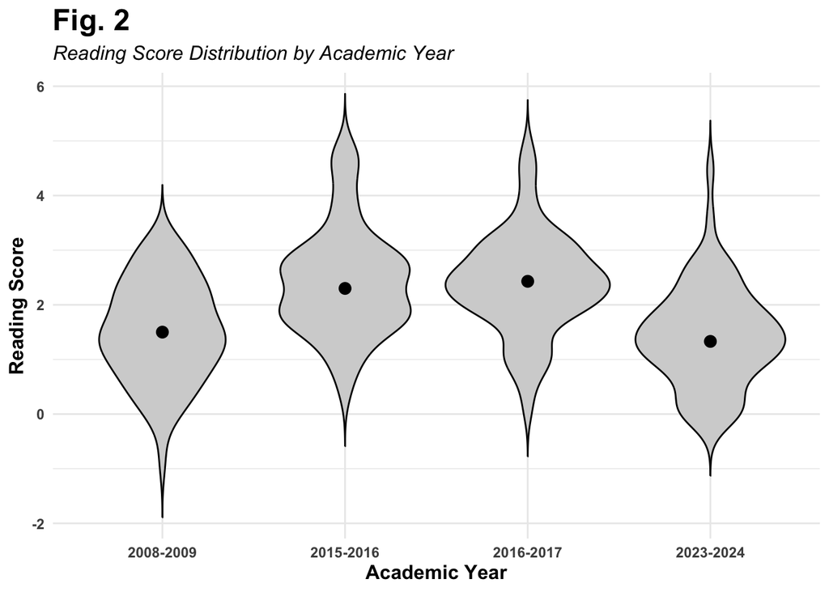

#### *Writing*

```
## Linear mixed model fit by REML. t-tests use Satterthwaite's method [
## lmerModLmerTest]
## Formula: writing ~ year + (1 | id)
##    Data: analysis_avgs
##
## REML criterion at convergence: 842.9
##
## Scaled residuals:
##     Min      1Q  Median      3Q     Max
## -2.3664 -0.6248 -0.1401  0.6041  3.9599
##
## Random effects:
##  Groups   Name        Variance Std.Dev.
##  id       (Intercept) 0.000    0.000
##  Residual             1.805    1.344
## Number of obs: 245, groups:  id, 192
##
## Fixed effects:
##               Estimate Std. Error       df t value Pr(>|t|)
## (Intercept)     1.9095     0.1521 242.0000  12.552  < 2e-16 ***
## year2015-2016   0.6650     0.2138 242.0000   3.110  0.00209 **
## year2016-2017   0.5488     0.2095 242.0000   2.619  0.00937 **
## ---
## Signif. codes:  0 '***' 0.001 '**' 0.01 '*' 0.05 '.' 0.1 ' ' 1
##
## Correlation of Fixed Effects:
##             (Intr) y2015-
## yr2015-2016 -0.712
## yr2016-2017 -0.726  0.517
## optimizer (nloptwrap) convergence code: 0 (OK)
## boundary (singular) fit: see help('isSingular')
```

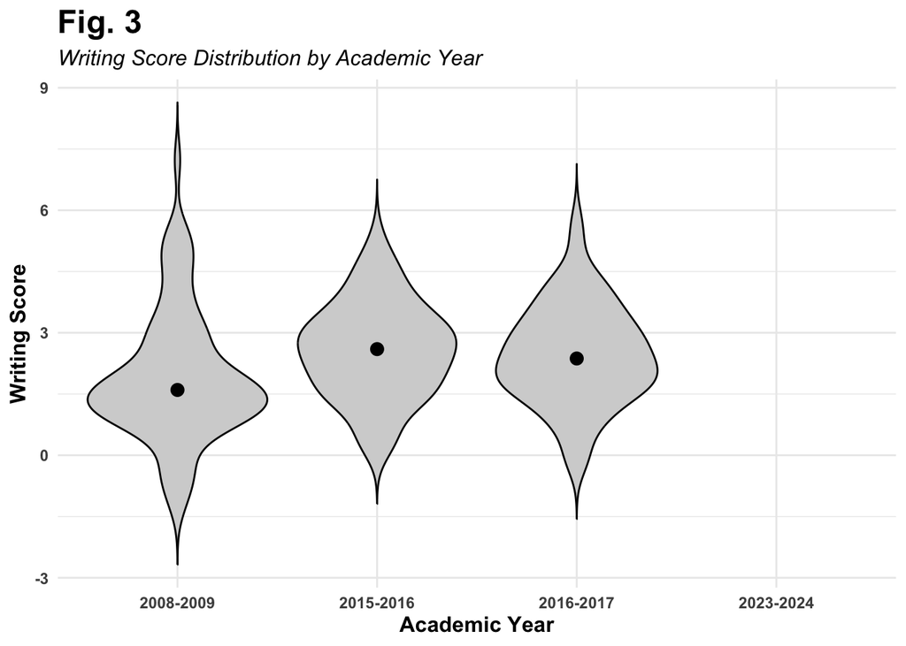

#### *Math*

```
##
## Call:
## lm(formula = math ~ year, data = analysis_avgs)
##
## Residuals:
##    Min     1Q Median     3Q    Max
## -7.553 -0.980 -0.180  0.872  7.447
##
## Coefficients:
##               Estimate Std. Error t value Pr(>|t|)
## (Intercept)     1.9032     0.1769  10.761   <2e-16 ***
## year2015-2016   0.6188     0.2456   2.519   0.0124 *
## year2023-2024   0.4768     0.2572   1.854   0.0650 .
## ---
## Signif. codes:  0 '***' 0.001 '**' 0.01 '*' 0.05 '.' 0.1 ' ' 1
##
## Residual standard error: 1.562 on 229 degrees of freedom
##   (115 observations deleted due to missingness)
## Multiple R-squared:  0.02898,    Adjusted R-squared:  0.0205
## F-statistic: 3.417 on 2 and 229 DF,  p-value: 0.03448
```

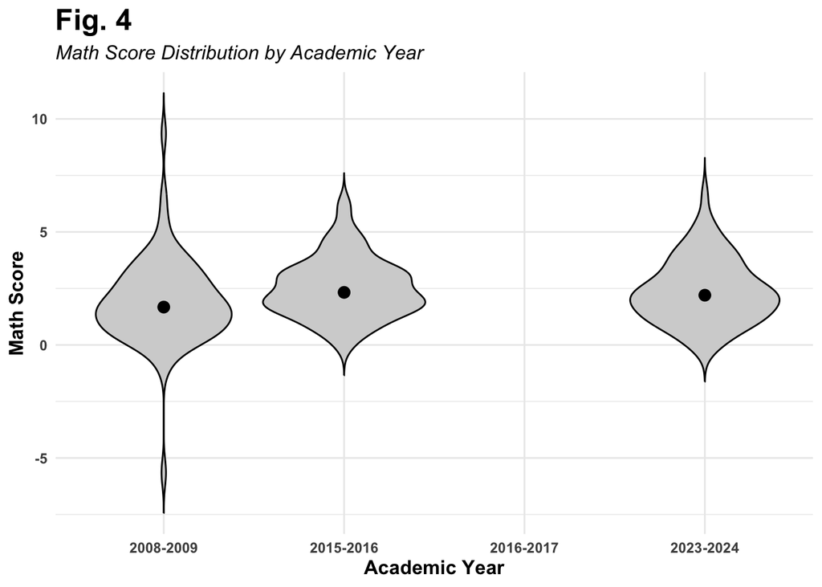

# **Discussion**

The main goal of this research paper is to provide evidence for the effectiveness of the Morningside Model of Generative Instruction for children behind in their educational capabilities. We used four waves of longitudinal data from the Morningside Academy in Seattle, Washington, specifically 2008-2009; 2015-2016; 2016-2017, and 2023-2024. Focusing on multiple waves allowed us to establish a more precise view of the educational process in this institution and account for fluctuations across the years and domains. Our main focus of the analysis was on the macro level of testing used, the pre- and post-test, as this is the participants’ most important measurement of growth (Street & Johnson, 2014). The descriptive statistics showed that this model is effective in educational settings and provided evidence that using scientific learning and a task-oriented environment supports the progress of students, similar findings have been documented in previous research (Johnson & Street, 2013). Both reading, writing, and math domain scores are higher compared to the initial ones, those result echoes previous research conducted in the scholarship (Johnson & Street, 2004). Being effective in this setting and providing the promised educational advances is crucial for the funding of the academy, considering the vast dependency on tuition. This model can be sufficient, however, more governmental support might be beneficial in the long term, reducing the threat of possible closure due to a year or two of lower results, which can be based on external factors and not on the quality of education.

Our first research question concerns the growth in the academic domain for the chosen period, we found support that growth scores varied across assessment types. The data showed significantly lower reading growth in comparison to math and writing, which were on similar levels. Special education is beneficial for students with disabilities and clinical disorders and improves their reading, math, and writing (Mayes & Calhoun, 2006). Focusing on math and writing growth, we can conclude that the MMGI model yields a positive effect on students in these institutions, improving their abilities. These findings contradict emerging evidence on the effectiveness of special education that questions the practice (Kvande et al., 2019), or found a negative correlation between special education and reading and math abilities in the case of preschoolers (Sullivan & Field, 2013), and math and language skills (Lekhal, 2018). When considering reading, improvement has been documented (Ehrhardt et al., 2013), contradicting our data. The reason for the limited reading growth in our sample might be the ceiling effect, due to the measurements. Additionally, math and writing are usually domains more likely to require interventions. There are vast differences in how special education is positioned and conducted in different countries and contexts, therefore more research will be needed to expand on these contradictory findings.